# Biochemistry R Introduction Part 1

Ben Dickins and Callum Rimmer

2023-03-31

# Tutorial Part 1: Penguins!

In this part, we will have some fun with the Palmer Penguins dataset, and we will shoehorn in a statistical learning outcome: understanding Simpson’s Paradox. We will start with a simple example and gradually add features to create the final plot. By the end of this tutorial, you will be able to create a visually appealing plot with custom colours, labels, and a linear regression line.

If you want to “meet the penguins” properly take a look at the [Palmer Penguins page](https://allisonhorst.github.io/palmerpenguins/articles/intro.html).

## Required Packages

You need to have the following R packages installed:

1. ggplot2: for creating the plots (part of “tidyverse” - more later)
2. palmerpenguins: for the penguin dataset

You can install them using the following commands:

```r
install.packages("ggplot2")
install.packages("palmerpenguins")
```

Now, let’s start by loading the required packages:

```r
library(ggplot2)
library(palmerpenguins)
```

## Step 1: Basic Data Inspection

The `palmerpenguins` library contains the dataset we need so we can just ask it to load with this command:

```r
data(penguins)
```

Now let’s look at the data by writing it’s name:

```r
penguins
```

```
## # A tibble: 344 × 8
##    species island    bill_length_mm bill_depth_mm flipper_…¹ body_…² sex    year
##    <fct>   <fct>              <dbl>         <dbl>      <int>   <int> <fct> <int>
##  1 Adelie  Torgersen           39.1          18.7        181    3750 male   2007
##  2 Adelie  Torgersen           39.5          17.4        186    3800 fema…  2007
##  3 Adelie  Torgersen           40.3          18          195    3250 fema…  2007
##  4 Adelie  Torgersen           NA            NA           NA      NA <NA>   2007
##  5 Adelie  Torgersen           36.7          19.3        193    3450 fema…  2007
##  6 Adelie  Torgersen           39.3          20.6        190    3650 male   2007
##  7 Adelie  Torgersen           38.9          17.8        181    3625 fema…  2007
##  8 Adelie  Torgersen           39.2          19.6        195    4675 male   2007
##  9 Adelie  Torgersen           34.1          18.1        193    3475 <NA>   2007
## 10 Adelie  Torgersen           42            20.2        190    4250 <NA>   2007
## # … with 334 more rows, and abbreviated variable names ¹flipper_length_mm,
## #   ²body_mass_g
```

In the class I will show you a few other ways to look at the data. Notice the presence of missing data (`NA`) and the labelling of columns with headers and “metadata” (specification of type of data present, e.g., `fct` which means “factor”).

## Step 2: Making Basic Plots

First let’s try a simple univariate plot of the penguins’ weight using ggplot2:

```
## Warning: Removed 2 rows containing non-finite values (`stat_bin()`).
```

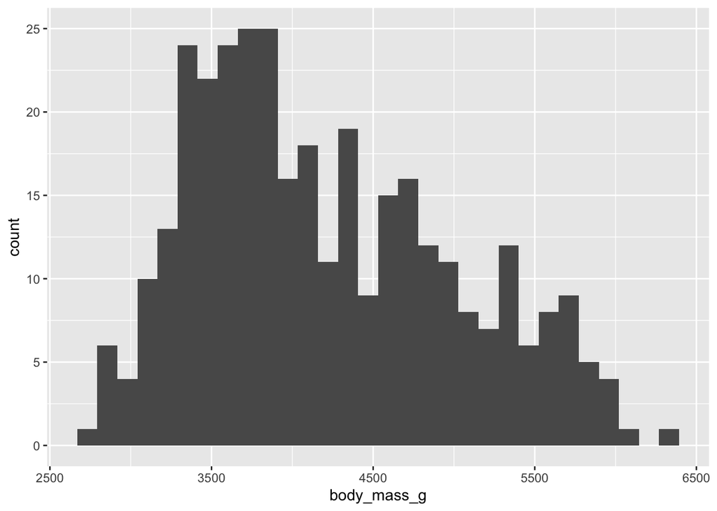

```r
ggplot(data = penguins, aes(x = body_mass_g)) + geom_histogram()
```

This is the typical form of all ggplot2 plots. The first function `ggplot()` is used to identify the data (`data = penguins`) and the aesthetic mapping (inside the `aes()` function), then we have a `+` follow by the “geom” that is the geometric construction that will be used to represent variation in the (aesthetically) mapped variable: here, a histogram. There is much more you can control here, but we will focus on bivariate plots in this tutorial. The warnings relate to the difficulty of plotting `NA` since this is not a finite value. `NA`s cause warnings and this is good - you should be thinking about them.

So let’s try another plot. This time let’s see how body mass (on the ordinate) is affected by penguin species (on the abscissa):

```
## Warning: Removed 2 rows containing non-finite values (`stat_boxplot()`).
```

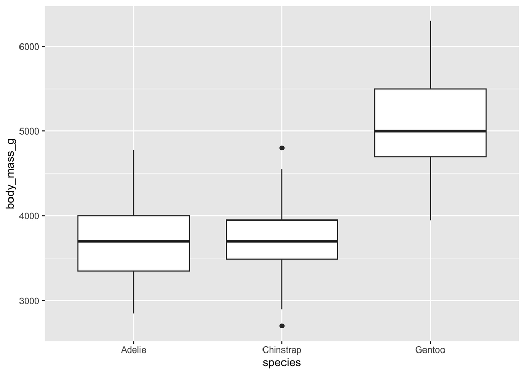

```r
ggplot(data = penguins, aes(x = species, y = body_mass_g)) +
  geom_boxplot()
```

Here `ggplot` has taken care of all the organisation and has calculated quartiles, outliers, etc. Notice that we were able to add the `geom_boxplot()` function on a new line. This wouldn’t usually work in R because each time you press “enter” you are entering a new command, but it works here because the previous line ended with a `+`.

If you want confidence intervals on your box plots you can add the argument `notch = TRUE` inside the brackets of `geom_boxplot()`. If you prefer kernel density estimation, try `geom_violin()` instead of `geom_boxplot()`. Loads of options!

## Step 3: The Classic Bivariate Approach: Scatter Plot

Now, let’s create a basic scatter plot of penguin bill dimensions:

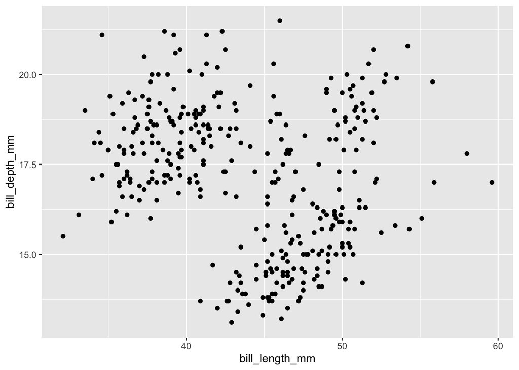

```r
ggplot(penguins, aes(x = bill_length_mm, y = bill_depth_mm)) +
  geom_point()
```

Here, we added `geom_point()` to create a scatter plot, and because I’m lazy I just wrote `penguins` rather than `data = penguins` in the `ggplot()` function because the function expects that the first argument will be the data. You should be feeling a little more comfortable now. These plots all look similar. You are beginning to learn the “grammar of graphics” after which ggplot2 is named.

## Step 4: Add Custom colours

Now, let’s add custom colours to the points in our scatter plot. We will add `colour = species` to the aesthetic mapping to differentiate points by species.

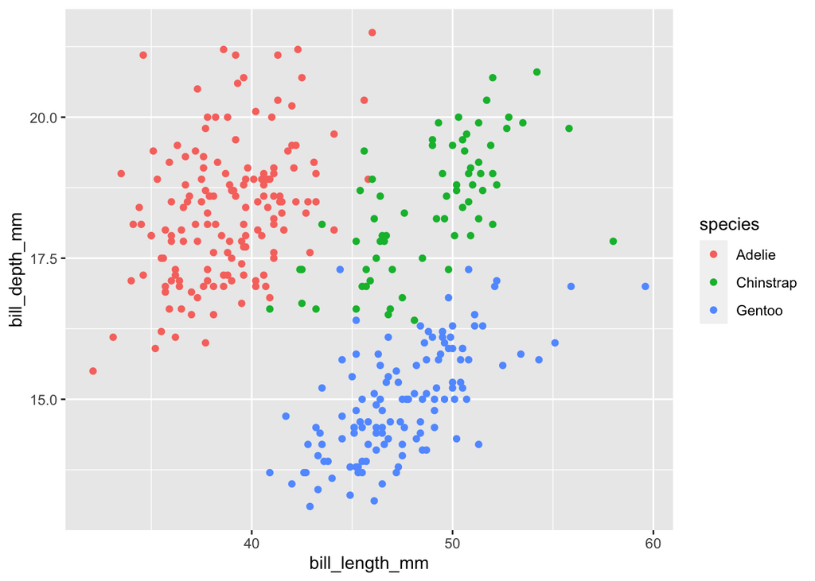

```r
ggplot(penguins, aes(x = bill_length_mm, y = bill_depth_mm, colour = species)) +
  geom_point()
```

Now we will manually set the colours using `scale_colour_manual()` to assign “darkorange”, “purple”, and “cyan4” to the three species:

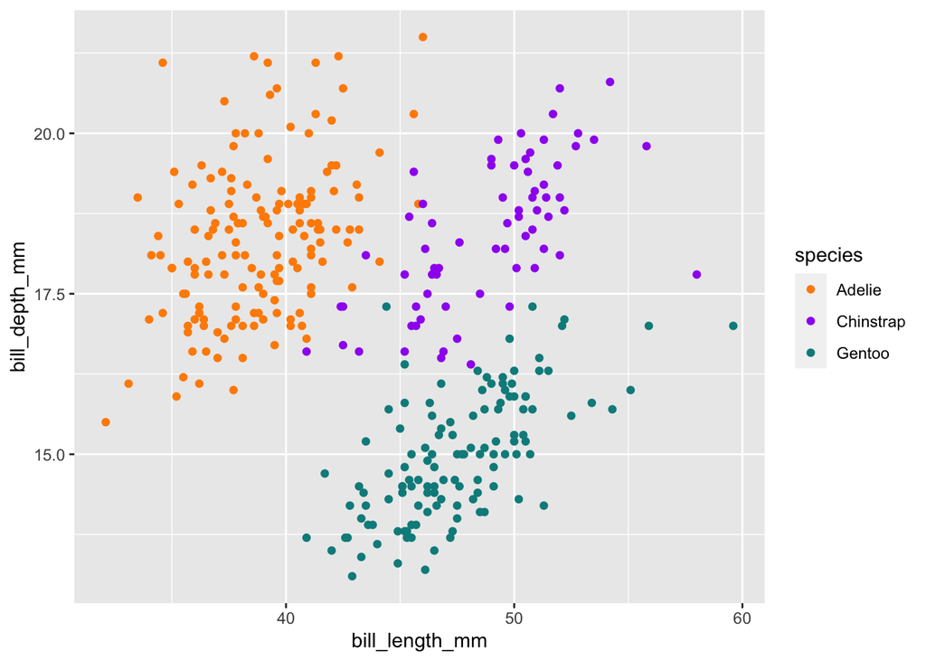

```r
ggplot(penguins, aes(x = bill_length_mm, y = bill_depth_mm, colour = species)) +
  geom_point() +
  scale_colour_manual(values = c("darkorange", "purple", "cyan4"))
```

There are also automatic palettes available. Check using `?scale_colour_discrete` for example.

## Step 5: Add Labels

Next, let’s add a title, subtitle, and axis labels to our plot using the labs() function:

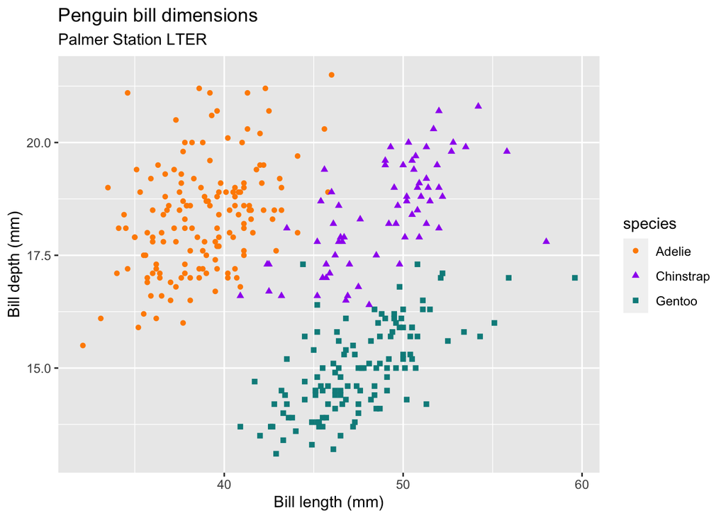

```r
ggplot(penguins, aes(x = bill_length_mm, y = bill_depth_mm)) +
  geom_point(aes(colour = species, shape = species)) +
  scale_colour_manual(values = c("darkorange", "purple", "cyan4")) +
  labs(title = "Penguin bill dimensions",
       subtitle = "Palmer Station LTER",
       x = "Bill length (mm)",
       y = "Bill depth (mm)")
```

We used `labs()` to add a title, subtitle, and axis labels to the plot. Notice that we have added a title and subtitle to the plot (not usually required) and we have altered the axis labels (by explicitly declaring them). Of course, you should be careful you get this manual step right and don’t label them as something they are not! R will do whatever you tell it to do, no matter how silly!

Notice that we also moved the `colour = species` argument into the `geom_point()` function inside an `aes()` function. The use of `aes()` as a wrapper means that the colour is calculated automatically, by species, exactly as in step 4. This is what aesthetic mapping is all about.

Can you see what the `shape = species` argument did? (Depending on the plot type, other aesthetic mappings are available such as “fill”).

## Step 6: Add Trendline

Now let’s try a simplified version with a linear trend line:

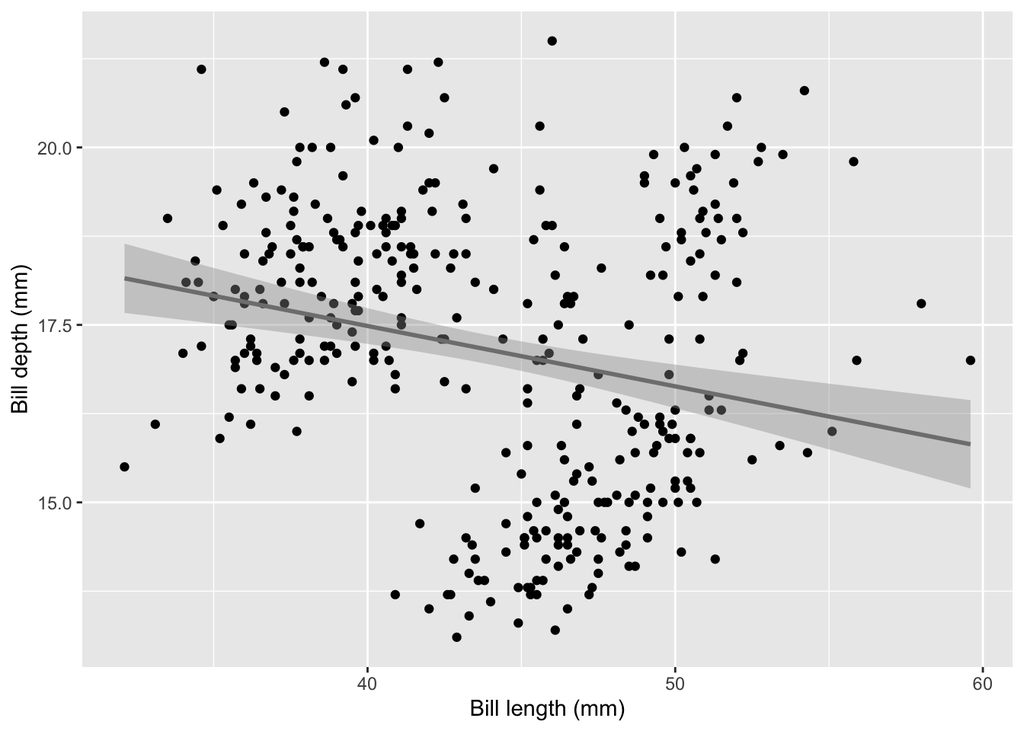

```r
ggplot(penguins, aes(x = bill_length_mm, y = bill_depth_mm)) +
  geom_point() +
  geom_smooth(method = "lm", se = TRUE, colour = "grey50") +
  labs(x = "Bill length (mm)", y = "Bill depth (mm)")
```

## Step 5: Down to You

What does this lead you to conclude about the association between bill length and bill depth?

You may find the [Wikipedia page on Simpson’s Paradox](https://en.wikipedia.org/wiki/Simpson's_paradox) useful.